# 统计陷阱读书报告

samsen

12/01/2015

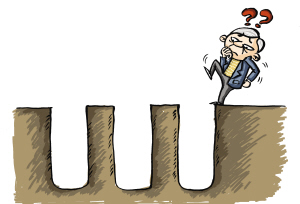

**中心思想：样本分析 -> 总体情况**

## 五个主题词

> - 谁说的？
> - 如何知道的？
> - 遗漏了什么?
> - 是否偷换了概念？
> - 有什么意义？

**统计陷阱读书报告目录**

> - 内在有偏的样本
> - 精心挑选的平均数
> - 没有披露的数据 && 毫无意义的工作
> - 惊人的统计图形 &&平面图形
> - 不相匹配的资料
> - 相关关系和因果关系
> - 如何进行统计操纵
> - 对统计资料提出的五个问题

## 内在有偏的样本

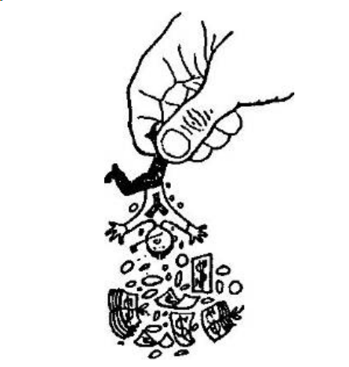

### “1924级耶鲁毕业生平均收入25111美元”

> **谁说的？**
> > - 出自耶鲁人之口

> **他如何知道的？**
> > - 通过抽样的问卷调查反馈的数据求出平均数，等价到“耶鲁人”的平均收入

> **是否遗漏了什么？**
> > - 平均是什么平均？
> > - 相比之下哈佛毕业生薪水是多少？
> > - 接受数据的人中给出的数据是他们真实的数据吗？
> > - 接受问卷调查但是未予反馈信息的以及联系不上的那些耶鲁毕业生的数据有吗？————由此想到的：当前电商数据的挖掘热很大程度上是由于所记录的用户行为数据的真实性

> **是否偷换了概念？**
> > - 其实是接受调查并且给予反馈的那些耶鲁人才是样本，无法有效反应“耶鲁人”这一总体

> **是否有意义？**
> > - 如果用于正式的资料，那毫无意
> > - 确实在一定程度上能说明部分耶鲁毕业生还是挺有钱的

`由此联想到的：浙江大学软件学院招生办的广告：2013届毕业生人均起薪14万，发人深思`

## 精心挑选的平均数

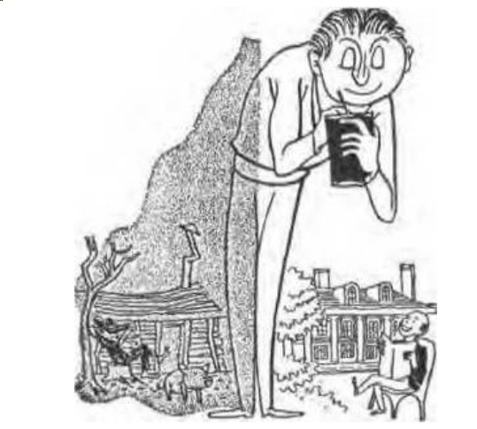

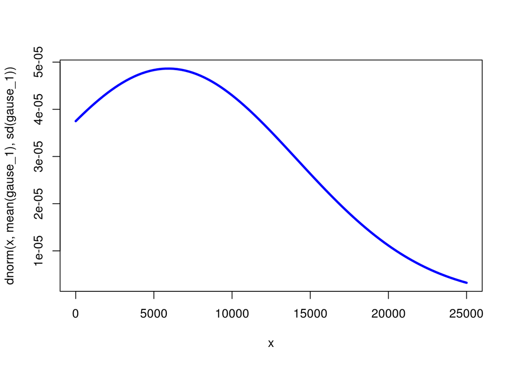

**如果有1/10的数量是老板，薪水大致为30000，去掉他们的薪水后：**

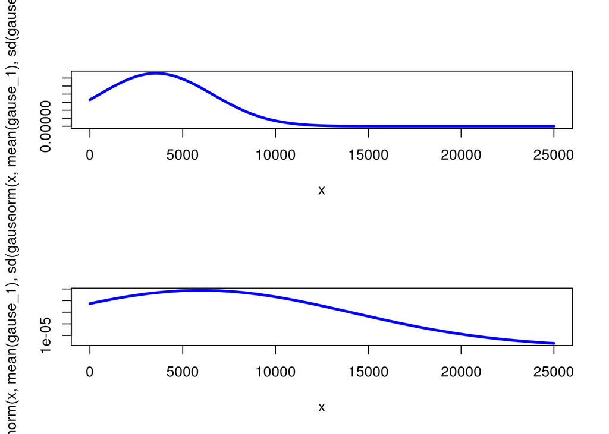

**启发：**

```
1.作为读者时：养成习惯，看到用于反映总体情况的数据时，要思考到底用的是哪一种指标，平均数、中位数还是众数？
2.作为作者时：写下去的时候要思考清楚，这里我该用哪种指标能更好地反映总体。对于不同的应用场景考虑不同的方案，参考：浙大软院招生办做法。
```

## 没有披露的数据 && 毫无意义的工作

[figure not shown]

**该牙膏提效了28%**

```
1.实验了很少的次数，成功率达到一定的频率，直接拿来推敲出结果（抽样的不充分性）
2.实验了N次，仅挑出好的结果作为宣传噱头（道德层面的问题）
```

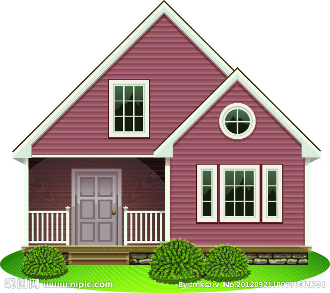

**美国房产商开发时统计家庭人口情况**

```
如果只得到平均3.6人的家庭，可能会建造的房子大多都是满足3~4个人居住的卧室以及配套器具
```

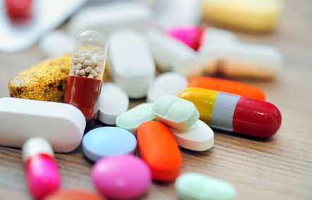

**感冒药广告：能在一周之内康复**

```
1.什么是康复？如何检测康复-其实看的还是感冒的外在症状
2.不吃这个药康复的时间如何--其实差不多
3.往往感冒有症状出现后会吃感冒药的人相对不吃药的人会更在意感冒，在一定程度上会更小心。即使症状消失的快一两天也是正常
```

**启发：**

```
1.作为读者时：对于**砖家**给出的很多报告要仔细思考，不假思索地接受绝对不是正确的做法
2.作为作者时：写出分析报告前尽可能地思考报告的东西是否实用、科学，能不能够有效结合业务，服务于业务
```

## 惊人的统计图形 &&平面图形

**斜率的应用**

国民收入走势：

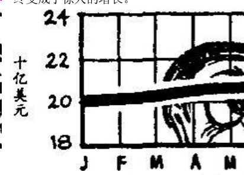

纵坐标间隔修改后：

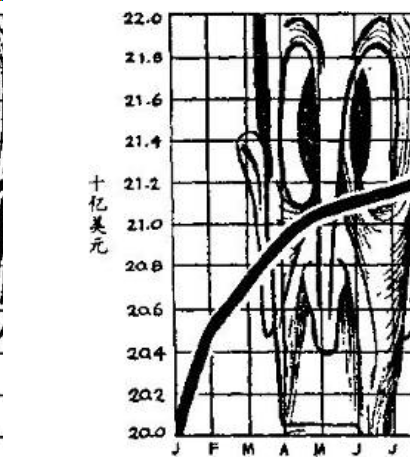

**“简略”的艺术**

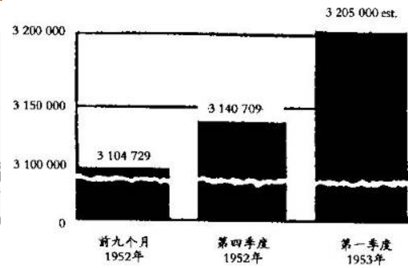

**图形的夸张效果**

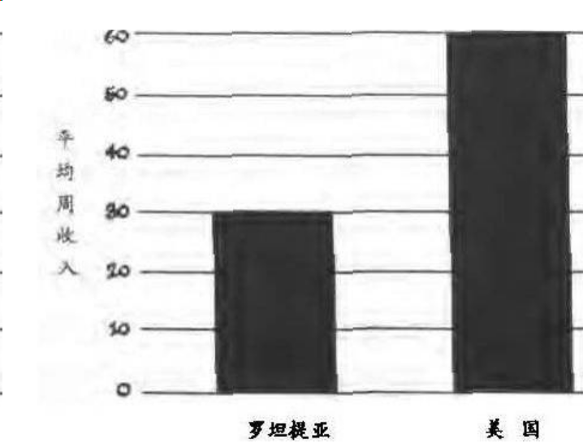

*加入稍许夸张的手法后：*

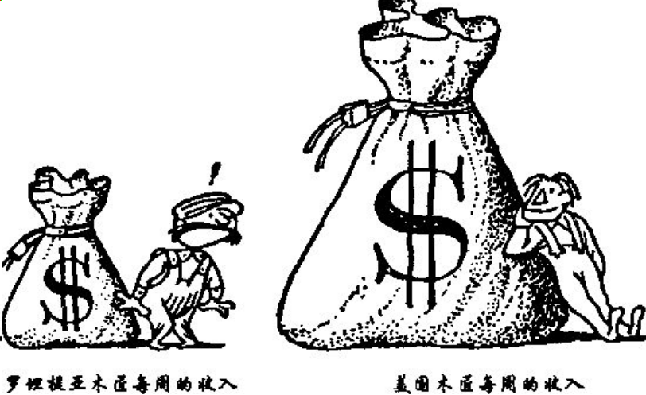

**启发：**

```
1.作为读者时：不能被图形的第一眼的直观感受所蒙蔽，要清楚自己真正想要了解的信息，读取它
2.作为作者时：绘图时尽可能地简单明确地展示出数据应该传达的信息
```

## 不相匹配的资料

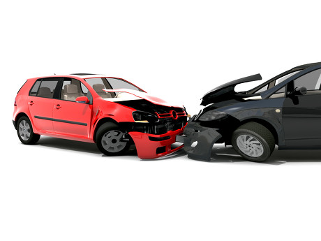

> - 2014年乘坐摩托车发生意外人数–50000
> - 2014年乘坐客车发生意外人数–100000
> - 2014年乘坐客车发生意外的人数比2004年多一倍

`能得出什么结论？ 是否摩托车比客车安全？是否现在的客车比以前客车更不安全？`

**A:其实是没披露完整的数据-但容易给读者产生误导，带来无谓的恐慌**

**启发：**

```
1.作为读者时：思考这些披露的数据到底是否能说明一个现象还是在简单地不负责任地陈述
2.作为作者时：撰写分析报告时要慎重，要严谨，千万不能给他们带来误导
```

## 相关关系和因果关系

**一副简单的散点图**

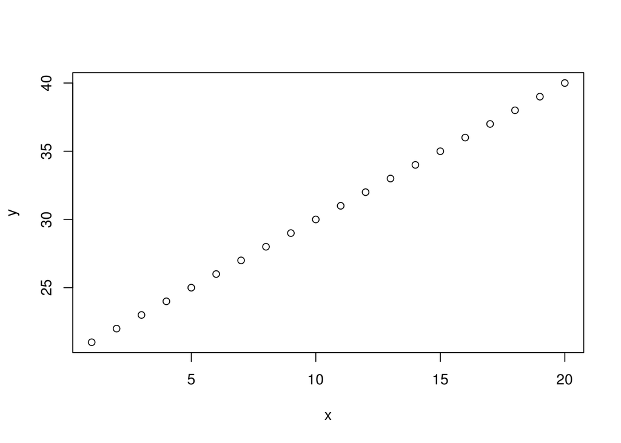

`究竟是X的增大能导致Y的增大还是Y的增大导致X的增大？`

**Answer:仅仅从统计分析的角度，能得出的结论只能是：X、Y往往具有相同的变化的趋势**

```
例子：1975年Ziel等人调查了110万妇女的病历（不是直接检查所有人），得出服用雌激素和发生子宫内膜癌之间有关联的结论。此结果在1979年被质疑，因为服用雌激素会刺激子宫内膜增生，易发生子宫出血，从而促进了求医行为
```

`相关性的作用？`

**Answer:可以帮助做出合理的猜测**

**启发：**

```
1.作为读者时：阅读相关的分析报告时可以了解了解哪些因素可能存在联系，对于有兴趣的点可以去深挖
2.作为作者时：不能混淆相关和因果，不能妄下结论
```

## 如何进行统计操纵

> 结合上述的一些套路：
> > - 巧妙的运用各种指标————中位数、平均数………
> > - 巧妙的应用统计图形
> > - “适当的”隐藏一些信息

## 对统计资料提出的五个问题

> - 谁说的？
> - 如何知道的？
> - 遗漏了什么?
> - 是否偷换了概念？
> - 有什么意义？

**总结:数学本身是一种很严谨的工具，正是由于统计数字上的滥用与误导导致国人越来越不信任统计研究报告，作为未来的数据分析师，我们在摄入文献资料与统计报告时要甄别思考清楚，在撰写分析报告过程中要时刻警惕是否调入了统计的陷阱**

## End

[figure not shown]